# Renminbi Exchange-Rate Expectations and China’s Foreign Exchange Reserves: A Replication of Du, Ge and Qiao (2014)

Author

Jiancheng Du

Published

October 13, 2026

# Abstract

Du, Ge and Qiao (2014) estimate the relation between expectations of the renminbi–dollar exchange rate and the growth of China’s foreign exchange reserves, 2000-2011, with a model-based expectation (Model I) and a market-based expectation using the 12-month non-deliverable forward rate (NDF; Model II), in four exchange-rate regimes. From the data of the original document we reproduce 18 of 20 Model I and 23 of 24 Model II estimates by sign and significance, most because both estimates are insignificant. We correct standard errors labelled as *t*-statistics, an inflation growth factor used as a deflator, year-to-date GDP, coefficients read as percentages, standard errors that ignore the generated regressor, and Chow statistics that cannot be reproduced. The article’s one significant finding, the NDF coefficient for 2008-2011, survives every per-period correction, but it is negative: reserves grew faster when appreciation was priced. Model I shows no robust expectation effect.

**Keywords:** replication, exchange-rate expectations, foreign exchange reserves, China, generated regressors, non-deliverable forwards.

**JEL classification:** F31, F32, E58, C22, C87.

**Conflict of interest:** the author of this note is one of the authors of the study replicated here. The research was not funded by any party with an interest in its outcome.

**Use of AI tools and purpose of this report:** this replication was carried out mainly to conduct a full replication and reproducibility procedure using AI tools. The author used Claude Code (Anthropic) to draft planning documents, write the data-collection and estimation code, propose options for analytic decisions, and draft much of the text of this note. **This report is therefore not intended for submission or publication.** The AI tool supplied no data value, estimate or result: every number in this note is produced by code that reads the original sources and was run by the author. Every analytic decision was taken by the author and recorded in the dated decision log before the estimates it governs (Appendix A), except where this note declares a later change. The author reviewed all code and text and is responsible for them. Details are in `docs/ai_use.md` of the replication package.

# 1 Introduction

Du, Ge and Qiao (2014) estimate how expectations about the renminbi (RMB)–US dollar exchange rate affected the accumulation of China’s foreign exchange reserves (FER) between 2000 and 2011. They split the sample into four exchange-rate regimes and measure expectations in two ways: a forecast generated from a three-stage regression model (Model I) and the 12-month non-deliverable forward rate (NDF, Model II). The abstract states that both methods “indicated that the change of expectation of RMB exchange rate positively correlated to FER” (p. 327). The conclusions state that the expectation “had a significant impact on the FER recently”, as shown in Period 4 (June 2008 to December 2011), and that “before June 2006, the change of RMB exchange rate expectation did not affect the FER significantly because of exchange rate management” (p. 341). Of the eight published expectation coefficients, those marked as significant are: Model II, Period 4 (article Table 4, p. 339).

How much of China’s reserve accumulation was driven by expected appreciation was part of a wider debate (Prasad and Wei 2007). Under a managed exchange rate, an expected appreciation invites capital inflows, the central bank buys the foreign currency to slow the appreciation, and reserves grow; the purchases must then be sterilised at a cost (Obstfeld et al. 2010). Reserves were also explained as precautionary insurance or as a by-product of an export-led strategy (Aizenman and Lee 2007). An expectation effect, if it exists, therefore bears on whether reserve accumulation was a policy choice or a response to market pressure.

This note is a replication in the sense of the *Journal of Comments and Replications in Economics*: it assesses the reliability of the article’s claims. We do two things. First, we **reproduce** the published estimates from the data of the original document on which the article is based, which contains the full dataset and every test and estimation table (Section 4). Second, we **correct** twelve problems in the original analysis, one at a time, and show how each correction changes the estimated effect of expectations (Sections 5 and 6).

**Disclosure.** The author of this note is one of the authors of the original article. To prevent the replication from being steered towards a preferred result, every rule that selects data, specifications or classifications was written down, dated, *before* the estimates it governs were computed, and the code and results of each step were committed to git. These rules include which balance-of-payments series is used, which unit-root specification, which Model I specification counts as the reproduction, and when an estimate counts as reproduced. One of these rules was changed after estimation: the differencing convention. The rule fixed before estimation measured the first change of each period from the last month of the previous period. A condition for switching to differencing within each period was stated in advance (W4-11), the check it named was met (W4-25), and the switch was made and is reported, with results under the original rule as a sensitivity check (W4-27, W4-31). One correction outside the replication plan, a constant in stage 2 of Model I, was added after the first corrected estimates had been seen, and is reported as a separate step (W4-20). Two diagnoses in this note were also found after the results were seen and are marked as such (W4-26).

Each rule is recorded, with the options considered and the evidence, in a numbered decision log, which Appendix A lists. The log is kept off the public repository and is available on request. All code and all public data are available at https://github.com/du-jc/fer-replication; the only inputs that cannot be redistributed are the original document and the Wind NDF series (Section 7).

Section 2 describes the original study, Section 3 the data, Section 4 the reproduction, Section 5 the corrections, and Section 6 their effect on the conclusions. Section 7 explains how to reproduce every result, and Section 8 concludes.

# 2 The original study

## 2.1 Models

The article estimates two models of the monthly change in reserves, $\Delta FER_t$, separately in four periods. **Model I** builds an expected change of the exchange rate in three stages. Stage 1 regresses the change of the exchange rate (RMB per USD) on fundamentals:

$$\Delta ER_t = b_0 + b_1\,\Delta BOP_t + b_2\,\Delta i_t + b_3\,\Delta \pi_t + b_4\,\Delta GDP_t + x_t .
\tag{1}$$

Stage 2 forecasts the change of the exchange rate from its own past, without a constant. The original document is ambiguous about which series it projects: its equation (4-2) regresses the observed change on its own lags, while its tables label the stage-3 regressor with a double hat, which indicates the stage-1 fitted values. We estimate both. The primary form follows the double hat, the stage-1 fitted values, which the original authors intended.

$$\widehat{\Delta ER}_t = \sum_{s=1}^{j} a_s\,\widehat{\Delta ER}_{t-s} + e_t \qquad \text{(primary)},
\tag{2}$$

$$\Delta ER_t = \sum_{s=1}^{j} a_s\, \Delta ER_{t-s} + e_t \qquad \text{(alternative, as printed in equation (4-2))},
\tag{3}$$

with one to three lags. The headline specification (Section 4) uses the alternative form with 1 lag(s). In the alternative form the stage-3 regressor is a weighted sum of the past exchange-rate changes and does not depend on stage 1.

Stage 3 uses the fitted value $\widehat{\widehat{\Delta ER}}_t$ as the expectation:

$$\Delta FER_t = \tau_0 + \tau_1\,\widehat{\widehat{\Delta ER}}_t + \tau_2\,\Delta NX_t + \tau_3\,\Delta FDB_t + \tau_4\,\Delta FDI_t + y_t .
\tag{4}$$

The coefficients of stages 1 and 2 are estimated from all months of a period, so the fitted value for month *t* uses information from months after *t*. It is an in-sample fitted value, not an expectation that could have been formed at the time, although the article calls it a rational expectation (p. 327; p. 332). This holds for both forms of the stage-2 regressor and both differencing conventions (W4-17). This is a limitation of Model I that we do not correct in this note; Section 8 proposes how to address it in future work.

**Model II** replaces the generated expectation by the observed 12-month NDF:

$$\Delta FER_t = g_0 + g_1\,\Delta NDF_t + g_2\,\Delta GDP_t + g_3\,\Delta NX_t + g_4\,\Delta FDB_t + g_5\,\Delta FDI_t + w_t .
\tag{5}$$

The variables are defined in Table 2. In the original document, the regressions of Periods 1 and 3 have AR(1) errors (ARIMA(1,1,0)) and those of Periods 2 and 4 are estimated by OLS. The periods follow the exchange-rate regime (Table 1).

The article’s conceptual model (its Figure 1, p. 332) lets reserves affect the exchange rate and the expected exchange rate affect reserves. The estimated equations (p. 334) do not identify this loop: stage 1 omits reserves (equation 1), and each equation is estimated by single-equation methods. None of the estimated coefficients can therefore be read as a causal effect of expectations on reserves; they measure associations (W4-21). The original document itself names simultaneous equations as the approach for future research (Section 4.5), which is also a future research direction we propose in this report.

Table 1: Sample periods. Source: Du, Ge and Qiao (2014); original document, Chapter 3.

| Period | From | To | Months |
| --- | --- | --- | --- |
| 1 | 2000-01 | 2005-06 | 66 |
| 2 | 2005-07 | 2006-05 | 11 |
| 3 | 2006-06 | 2008-05 | 24 |
| 4 | 2008-06 | 2011-12 | 43 |

## 2.2 Reported findings

The article reads its Table 4 (p. 339) in Section 4.3 (p. 340-341). It reports that both expectation measures have positive coefficients in Periods 1 and 2, and negative ones in Periods 3 and 4, and attributes the change to the regime: before June 2006 the RMB was “managed or simply peg on the dollar”, after it “a basket of currency policy was adopted” (p. 341). Of the expectation coefficients, it reports only the NDF coefficient of Model II in Period 4 as significant, at the 5% level (p. 340-341), and calls it “positive” in one sentence and “negative” in another (Section 5, sign convention). Other coefficients are read as percentage effects (p. 340). From Chow tests, the article concludes that the determinants of reserves changed structurally between the periods (conclusion 2, p. 342), and it recommends “decreasing the expectation of RMB exchange rate and the amount of foreign debt balance” to keep reserves at a moderate scale (conclusion 3, p. 342).

# 3 Data

## 3.1 The original data

All data and all reproduction targets are read by code from the original document; nothing is transcribed by hand. Appendix I of the original document supplies nine monthly variables for the 144 months from January 2000 to December 2011 (Table 2). The extracted data were checked against the original study’s descriptive statistics (Tables 3.2 to 3.9): of the 304 cells of those tables, 267 agree to the printed decimals on the raw data (decision W2-13; tolerance: half a unit of the last printed digit, W2-07). The cells that do not agree to the printed decimals are of three kinds (W2-13). The Period 1 correlations involving the exchange rate are printed in the original document although the raw exchange rate is constant in Period 1, so these correlations are undefined; they are discrepancies of the original document. The Period 2 correlations involving the exchange rate, and a few means, standard deviations and correlations in other periods, differ from ours by small amounts. With the tolerance of 0.05, set after the comparison was seen (W2-07), only the Period 1 correlations remain unmatched. Our interpretation suggests that the small gaps arise because the original computed its statistics from data with more decimals than the appendix prints. This does not explain the Period 1 correlations, which are undefined on the raw data.

Table 2: Variables. Source: original Appendix I; SAFE; Wind; labels corrected where the original is inaccurate (Section 5).

| symbol | label | source |
| --- | --- | --- |
| FER | foreign exchange reserves | original Appendix I |
| ER | exchange rate, RMB per USD (a rise is a depreciation of the RMB) | original Appendix I |
| NDF | 12-month USD/CNY non-deliverable forward, RMB per USD (Wind series in the source ledger) | Wind |
| BOP | balance of payments, current account (SAFE BPM6 row 1), quarterly converted to monthly (W2-10) | SAFE |
| GDP | GDP: cumulative year-to-date in the appendix; discrete quarterly in versions gdpq and corrected | original Appendix I |
| pi | CPI, same month of the previous year = 100 (a growth factor, not a price level) | original Appendix I |
| i | nominal one-year deposit rate (labelled 'real' in the article) | original Appendix I |
| NX | net exports | original Appendix I |
| FDI | foreign direct investment | original Appendix I |
| FDB | external debt stock | original Appendix I |

## 3.2 Inputs not in the original appendix

Two regressors are not in the appendix and were collected anew, and price data were added for the corrections (Table 3; State Administration of Foreign Exchange (2026); Wind Information Co. (2026); International Monetary Fund (2026); Organisation for Economic Co-operation and Development (2026); National Bureau of Statistics of China (2026)).

- **Balance of payments.** The quarterly current account (SAFE, BPM6 presentation) is converted to months. Of three candidate conversions (quarterly value held, divided by three, year-to-date), the one used, bop_ca_ytd, was chosen by a rule fixed before any Model I estimate. The rule combines the distance to the original unit-root statistic and to the four stage-1 Durbin–Watson statistics (W2-01, W2-10, W2-12).[^1]
- **NDF.** The 12-month USD/CNY NDF is the only Wind tenor that covers 2000–2011. Month-end and month-average versions of the daily series were compared with the original unit-root statistic before Model II was estimated; the version used is ndf_mend (W2-06, W2-10).
- **Consumer prices.** For the deflator correction (Section 5.7), a fixed-base consumer price index for China was taken from the IMF data portal and cross-checked against FRED (OECD data). The NBS published year-on-year index (same month of the previous year = 100) was used to identify the original study’s inflation series (W4-05, W4-14).

Table 3: Data sources. Coverage: first and last observation in the file as downloaded. Layer rep: used in the analysis; check: used only to verify another series. Source: data/metadata/source_ledger.csv of the replication package.

| Series | Provider | Code | Frequency | Coverage | Method | Layer | Licence or access |
| --- | --- | --- | --- | --- | --- | --- | --- |
| Original document Appendix I (9 variables) and Tables 3.1-4.11 | Original study document underlying Du, Ge & Qiao (2014) | App. I; T3.1, T3.2, T3.3, T3.4, T3.5, T3.6, T3.7, T3.8, T3.9, T4.1, T4.2, T4.3, T4.4, T4.5, T4.6, T4.7, T4.8, T4.9, T4.10, T4.11 | monthly (App. I); period statistics and test tables | 2000-01 to 2011-12 | document extraction | rep | Unpublished original study document (co-author's); used for replication only. Not committed to git and not redistributed (decision W1-02). |
| BOP 1. 经常账户 (current account balance), BPM6, quarterly | State Administration of Foreign Exchange (SAFE) | sheet4:1. 经常账户 | quarterly | 1998-Q1 to 2026-Q2 | file download | rep | Public official statistics (SAFE website); reproduction with attribution |
| 无本金交割远期外汇(NDF):美元兑人民币:12个月 | Wind Information Co. (Wind Financial Terminal) | G0008386 | daily | 1999-01-19 to 2026-09-23 | manual proprietary | rep | Proprietary Wind data exported by a licensed Wind user; not redistributable; kept in git-ignored data/raw/ proprietary/ |
| Consumer price index, all items, China (IMF CPI dataflow) | International Monetary Fund (IMF data portal) | IMF.STA/CPI/ CHN.CPI._T.IX.M | monthly | 1993-01 to 2026-08 | api | rep | IMF data, free of charge; cite the IMF data portal (IMF terms of use) |
| Consumer Price Indices (CPIs, HICPs), COICOP 1999: Consumer Price Index: Total for China | FRED, Federal Reserve Bank of St. Louis (source: OECD Main Economic Indicators) | CHNCPIALLMINMEI | Monthly | 1993-01 to 2025-04 | api | check | OECD data via FRED; cite OECD and FRED as FRED requests |
| 居民消费价格指数 (上年同月=100) (CPI, same month of the previous year = 100) | National Bureau of Statistics of China (NBS), data.stats.gov.cn | nbs:居民消费价格指数(上年同月=100) | monthly | 1998-01 to 2015-12 | file download | check | Public official statistics (NBS); cite the National Bureau of Statistics |

# 4 Reproduction

## 4.1 Procedure

The reproduction follows rules fixed before estimation. Because the original document does not fully document Model I, all twelve combinations of its undocumented choices were estimated. These choices are whether stage 2 projects the stage-1 fitted values or the observed exchange rate, the number of lags (one to three), and whether the variables are used as published or divided by $\pi/100$, as the article states. The combination that reproduces most published cells was then named the headline (W3-02). Each estimate is classified on its sign and star level only (W1-07), with the meanings of *, ** and *** taken from the notes of the original table 4 (p. 339) and significance meaning *p* < 0.10; the dagger, which those notes do not define and which appears once in the original table, is read as *p* < 0.10 (W4-16). An estimate is **reproduced** if it has the same sign and the same star level as the published one, or if both are insignificant; **partially reproduced** if both are significant with the same sign but a different star level; and **not reproduced** if significance flips, or if the signs differ and either estimate is significant. Magnitude, measured as the gap in published standard errors, is reported but does not affect the class. First differences, and the lags of stage 2, are taken within each period, as if each period were a separate dataset, so that the first month of each period is lost to differencing (the “within” convention). This is a change made after estimation. The convention fixed beforehand took differences on the whole 2000-2011 series, so that the first change of a period was measured from the last month of the previous one (W3-01). The switch followed a condition stated in advance, that the Durbin-Watson bounds printed in the original document should imply within-period samples (W4-11, W4-25, W4-27). Both conventions use only current and past months. Results under full-sample differencing are reported as a sensitivity check (W4-31).

## 4.2 Unit-root tests

The article (Du et al. 2014) and the text of the original document (its Section 4.1.1) describe the unit-root test as an augmented Dickey-Fuller (ADF) test; the tables of the original document report DF-GLS (Elliott et al. 1996). The original document does not state its lag rule. The specification that best reproduces the original statistics of the eight appendix variables was selected and then fixed (W2-02, W2-09). Table 4 shows the original statistics, our DF-GLS statistics and the ADF statistics at the same lag. DF-GLS and ADF agree on rejection at 5% in 14 of 14 series. Our DF-GLS statistics agree with the original’s to the printed decimals for some series and differ slightly for the others (Table 4). No stationarity judgment at the 5% level differs from the original’s (W2-09). The specification that achieves this closeness uses a fixed lag of one, which is not a documented lag-selection rule; it was chosen because it reproduces the original statistics, and it is reported as such.

Table 4: Unit-root tests. Source: original Tables 4.1 and 4.2; own calculations.

| variable | lags | original dfgls | dfgls | dfgls cv5 | dfgls rejects | adf | adf cv5 | adf rejects | original stationary |
| --- | --- | --- | --- | --- | --- | --- | --- | --- | --- |
| FER | 1 | 0.249 | 0.249 | -2.93 | no | -1.861 | -3.43 | no | No |
| GDP | 1 | -5.22 | -5.221 | -2.93 | yes | -5.617 | -3.43 | yes | Yes |
| ER | 1 | -0.952 | -0.93 | -2.93 | no | -1.881 | -3.43 | no | No |
| NX | 1 | -4.135 | -4.135 | -2.93 | yes | -4.324 | -3.43 | yes | Yes |
| FDI | 1 | -6.72 | -6.721 | -2.93 | yes | -7.712 | -3.43 | yes | Yes |
| FDB | 1 | -0.069 | -0.069 | -2.93 | no | -0.344 | -3.43 | no | No |
| i | 1 | -1.805 | -1.805 | -2.93 | no | -1.958 | -3.43 | no | No |
| DFER | 1 | -6.386 | -6.386 | -2.93 | yes | -7.615 | -3.43 | yes | Yes |
| DGDP | 1 | -8.006 | -8.006 | -2.93 | yes | -8.315 | -3.43 | yes | Yes |
| DER | 1 | -5.047 | -5.01 | -2.93 | yes | -6.417 | -3.43 | yes | Yes |
| DNX | 1 | -8.543 | -8.543 | -2.93 | yes | -8.905 | -3.43 | yes | Yes |
| DFDI | 1 | -14.724 | -14.723 | -2.93 | yes | -18.242 | -3.43 | yes | Yes |
| DFDB | 1 | -11.026 | -11.025 | -2.93 | yes | -11.556 | -3.43 | yes | Yes |
| Di | 1 | -5.748 | -5.753 | -2.93 | yes | -5.984 | -3.43 | yes | Yes |

<sup>a</sup> Original DF-GLS: original Tables 4.1 (levels) and 4.2 (first differences). Our DF-GLS and ADF use the specification fixed in Week 2 (deflated/trend/common/fixed_1) and the same number of lags.  
<sup>b</sup> Critical values at 5%: DF-GLS from urca (Elliott, Rothenberg and Stock 1996 tables), ADF from urca (Dickey-Fuller tables). The original’s critical values (Stata dfgls, finite-sample) differ by construction; compare the statistics.  
<sup>c</sup> Rejects: the unit-root null is rejected at 5%.

## 4.3 Estimates

The headline Model I specification uses the alternative stage-2 regressor with 1 lag(s) on deflated data. It reproduces 18 of the 20 Model I cells; 1 are partially reproduced and 1 not reproduced. The ranking among the 12 combinations was decided by count (W3-07). For Model II on deflated data, 23 of 24 cells are reproduced (W3-08). Because two insignificant estimates count as reproduced whatever their size, the counts rest largely on such cells (W3-14): of the reproduced Model I cells, 14 are insignificant in both the original and our estimates, and 13 lie within one published standard error of the published value; for Model II, 18 and 21. Tables 5 and 6 (Tables 4.9 and 4.10 in the original document; Table 4 in the article) set the published and the reproduced estimates side by side, and Figure 1 shows each gap in units of the published standard error.

Table 5: Published and reproduced estimates, Periods 1 and 2. Source: original Table 4.9 (= article Table 4); own estimates.

|  | P1 I published | P1 I reproduced | P1 II published | P1 II reproduced | P2 I published | P2 I reproduced | P2 II published | P2 II reproduced |
| --- | --- | --- | --- | --- | --- | --- | --- | --- |
| Expected DER (stage 3) | 328.3027 | 4485.0782 |  |  | 164.2427 | 6689.5842 |  |  |
|  | (188.0208) | (11990.6425) |  |  | (1192.0540) | (8297.9355) |  |  |
| DNDF |  |  | 109.5668 | 111.4349 |  |  | 305.7626 | 255.1902 |
|  |  |  | (117.1090) | (116.9164) |  |  | (395.5048) | (402.8903) |
| DGDP |  |  | -0.0002 | -0.0002 |  |  | -0.0006 | -0.0007 |
|  |  |  | (0.0003) | (0.0003) |  |  | (0.0006) | (0.0006) |
| DNX | -0.2176 | -0.2615 | -0.2420 | -0.2369 | 0.5479 | 0.9067 | 0.3631 | 0.3680 |
|  | (0.4160) | (0.4731) | (0.5219) | (0.5200) | (0.7376) | (0.8082) | (0.6187) | (0.6331) |
| DFDB | -0.0900 | -0.0284 | -0.0264 | -0.0250 | -0.5976 | -0.3519 | 0.1028 | 0.0943 |
|  | (0.2196) | (0.2014) | (0.2393) | (0.2395) | (0.6362) | (0.6909) | (0.8068) | (0.8431) |
| DFDI | -0.3585 | -0.2537 | -0.1724 | -0.1788 | -0.9286 | -0.7207 | 1.1845 | 1.1822 |
|  | (0.5310) | (0.6714) | (0.6949) | (0.6944) | (2.3267) | (2.2532) | (2.8000) | (2.8629) |
| Constant | 0.8782** | 88.0940** | 0.8737 ** | 87.3992** |  |  |  |  |
|  | (0.3081) | (29.0996) | (0.3388) | (33.8384) |  |  |  |  |
| AR(1) | 0.6565*** | 0.6479*** | 0.6663*** | 0.6659*** |  |  |  |  |
|  | (0.0641) | (0.0686) | (0.0640) | (0.0642) |  |  |  |  |
| N | 65 | 64 | 65 | 65 |  | 9 |  | 10 |
| Estimator | ARIMA | ARIMA | ARIMA | ARIMA | OLS | OLS | OLS | OLS |

<sup>a</sup> Published: original Table 4.9 as printed (marks as printed); the numbers in parentheses are those printed below each coefficient, which the article labels t-statistics (see the section ‘Standard errors labelled as t-statistics’).  
<sup>b</sup> Reproduced: our estimates, Model I with the alternative stage-2 regressor and 1 lag(s) on deflated data (rank 1 under the pre-specified rule W3-02; result W3-07); Model II on the same data; differences on the within convention. Standard errors in parentheses: OPG for ARIMA periods, OLS otherwise.  
<sup>c</sup> n.i. = not identified: the regressor has no variation in that period (the exchange rate was pegged in Period 1).  
<sup>d</sup> Estimator: ARIMA = regression in first differences with AR(1) errors (ARIMA(1,1,0) in levels), exact maximum likelihood; OLS otherwise.  
<sup>e</sup> Our coefficients are rounded to the decimals printed in the original.  
<sup>f</sup> Shading of the reproduced estimates (classification W1-07, on sign and star level only; significant = p < 0.10): green = reproduced (same sign and same star level, or both insignificant); yellow = partially reproduced (same sign, both significant, different star level); red = not reproduced (significance flips, signs differ with either significant, or not identified).  
<sup>g</sup> Significance (legend of original Tables 4.9-4.10): † p < 0.1, * p < 0.05, ** p < 0.01, *** p < 0.001 (two-sided; normal for the ARIMA periods, t for OLS).  
<sup>h</sup> Periods: 1 = 2000-01 to 2005-06; 2 = 2005-07 to 2006-05; 3 = 2006-06 to 2008-05; 4 = 2008-06 to 2011-12 (Replication Plan s.3.3).

Table 6: Published and reproduced estimates, Periods 3 and 4. Source: original Table 4.10 (= article Table 4); own estimates.

|  | P3 I published | P3 I reproduced | P3 II published | P3 II reproduced | P4 I published | P4 I reproduced | P4 II published | P4 II reproduced |
| --- | --- | --- | --- | --- | --- | --- | --- | --- |
| Expected DER (stage 3) | -200.0742 | 1206.4542 |  |  | -4308.4840 | 1345.5273 |  |  |
|  | (476.6059) | (895.2252) |  |  | (8324.3310) | (4083.2915) |  |  |
| DNDF |  |  | -163.1845 | -154.8205 |  |  | -1294.4460* | -1288.8846* |
|  |  |  | (376.3561) | (343.0542) |  |  | (531.2001) | (531.0954) |
| DGDP |  |  | -.0007 | -0.0007 |  |  | 0.0008 | 0.0008 |
|  |  |  | (0.0007) | (0.0007) |  |  | (0.0007) | (0.0007) |
| DNX | 0.2384 | 0.0170 | .4362 | 0.4271 | -0.5519 | -0.5781 | -0.8213 | -0.8197 |
|  | (0.4853) | (0.4648) | (0.4542) | (0.4385) | (0.6736) | (0.6891) | (0.6352) | (0.6355) |
| DFDB | 0.4041 ** | 0.3504* | .4403* | 0.4435** | 0.5843 | 0.6607† | 0.4315 | 0.4327 |
|  | (0.1425) | (0.1670) | (0.1738) | (0.1699) | (0.3504) | (0.3397) | (0.3126) | (0.3128) |
| DFDI | -0.9285 | -1.1214 | -1.6370 | -1.6140 | -2.6346 | -2.3085 | -3.5087 | -3.5059 |
|  | (0.9880) | (0.8314) | (1.3808) | (1.3839) | (2.8110) | (2.7806) | (2.5477) | (2.5492) |
| Constant | 2.9458*** | 360.5096*** | 2.9920 *** | 299.4861*** |  |  |  |  |
|  | (0.6852) | (86.3933) | (0.7057) | (68.7489) |  |  |  |  |
| AR(1) | 0.5950 ** | 0.7096** | 0.6647† | 0.6613† |  |  |  |  |
|  | (0.2175) | (0.2331) | (0.3530) | (0.3497) |  |  |  |  |
| N | 23 | 22 | 23 | 23 |  | 41 |  | 42 |
| Estimator | ARIMA | ARIMA | ARIMA | ARIMA | OLS | OLS | OLS | OLS |

<sup>a</sup> Published: original Table 4.10 as printed (marks as printed); the numbers in parentheses are those printed below each coefficient, which the article labels t-statistics (see the section ‘Standard errors labelled as t-statistics’).  
<sup>b</sup> Reproduced: our estimates, Model I with the alternative stage-2 regressor and 1 lag(s) on deflated data (rank 1 under the pre-specified rule W3-02; result W3-07); Model II on the same data; differences on the within convention. Standard errors in parentheses: OPG for ARIMA periods, OLS otherwise.  
<sup>c</sup> n.i. = not identified: the regressor has no variation in that period (the exchange rate was pegged in Period 1).  
<sup>d</sup> Estimator: ARIMA = regression in first differences with AR(1) errors (ARIMA(1,1,0) in levels), exact maximum likelihood; OLS otherwise.  
<sup>e</sup> Our coefficients are rounded to the decimals printed in the original.  
<sup>f</sup> Shading of the reproduced estimates (classification W1-07, on sign and star level only; significant = p < 0.10): green = reproduced (same sign and same star level, or both insignificant); yellow = partially reproduced (same sign, both significant, different star level); red = not reproduced (significance flips, signs differ with either significant, or not identified).  
<sup>g</sup> Significance (legend of original Tables 4.9-4.10): † p < 0.1, * p < 0.05, ** p < 0.01, *** p < 0.001 (two-sided; normal for the ARIMA periods, t for OLS).  
<sup>h</sup> Periods: 1 = 2000-01 to 2005-06; 2 = 2005-07 to 2006-05; 3 = 2006-06 to 2008-05; 4 = 2008-06 to 2011-12 (Replication Plan s.3.3).

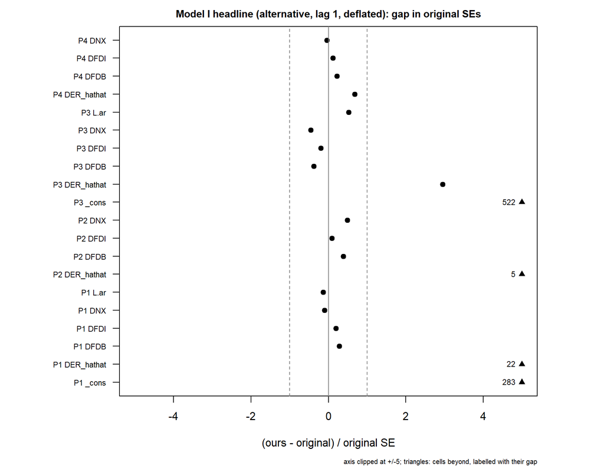

Figure 1: Gap between reproduced and published Model I estimates, in published standard errors (headline specification). Dashed lines: one standard error. Cells beyond the clipped axis are marked with triangles and labelled with their gap. Source: own estimates; original Tables 4.9-4.10.

The controls and the autoregressive error terms reproduce closely: of the 18 reproduced Model I cells, 13 lie within one published standard error of the published value. The expectation term does not. In each of the 4 periods its published and its reproduced coefficient are both insignificant, so the cell counts as reproduced under our rule (W1-07), but the sign differs in 2 of them and the gaps are large (Figure 1). Our interpretation suggests that the expectation term is the least reproducible part of Model I because it is a generated regressor: its values depend on choices that the original document does not report, namely the series that stage 2 projects, the lag order, whether stage 2 has a constant, and how the period samples were built (W3-02, W4-18, W4-19). Model II, whose expectation measure is observed rather than generated, reproduces closely, including its one significant expectation coefficient, in Period 4: -1,294.45* (SE 531.20) published and -1,288.88* (SE 531.10) reproduced.

The one Model I cell that is not reproduced, net external debt in Period 4, lies at the significance threshold. The published coefficient and standard error imply *p* = 0.095 (normal approximation), just below the 10% level at which our rule counts an estimate as significant, yet the published table leaves it unmarked: its legend defines marks only from 5% and a 10% mark appears once in the original tables (W4-16). Our estimate lies 0.22 published standard errors from the published value. Our interpretation suggests that this cell reflects the marking threshold, not a different estimate.

The constants of Periods 1 and 3 reproduce in sign and significance but not in size: ours are between 100 and 122 times the published values, in both models (Table 5, Table 6; W3-07). We examined two explanations.

The first is a constant in stage 2, which the printed equations (2, 3) omit but a default regression command would include. Before re-estimating, we fixed the rule for reading the result (W4-19). The explanation would count as likely if, with a stage-2 constant, both constants came within one published standard error of the published values and no other Model I cell changed class; as partial if both moved closer; and as ruled out otherwise. For the headline specification (alternative, lag 1, deflated), with a stage-2 constant (row 1c of Table 14), the Period 1 constant lies 300.74 published standard errors from the published value (283.08 without it) and the Period 3 constant 1618.55 (521.84); 0 other Model I cells change class. By the rule, the outcome is (c): the missing stage-2 constant is ruled out as the explanation of the constant gaps. The outcome is the same under the convention fixed before estimation (W4-22, W4-29).

The second explanation is a scaling of the data. The article states that “all variables are divided by inflation which is noted as π” (p. 334), where π is an index close to 100, while our deflated data, like the data printed in the article (Table 2, p. 335), divided by π/100. Dividing every variable by π instead of π/100 multiplies all of them by 1/100. Such a common rescaling leaves every slope, every autoregressive coefficient and every *t* statistic unchanged and divides the constant and its standard error by 100, which is the pattern in Tables 5 and 6. Rescaled by 1/100, our constants lie the following numbers of published standard errors from the published ones: Model I, Period 1: 0.01; Model I, Period 3: 0.96; Model II, Period 1: 0.00; Model II, Period 3: 0.00; 4 of the 4 are within one standard error. This diagnosis was found after the results were seen (W4-26). Our interpretation suggests that the original regressions used the variables divided by π, as the article’s text says, and that this accounts for the size of the published constants; no slope coefficient, and hence no conclusion of the article, is affected.

The sample sizes printed in the original document are matched in 4 of 28 comparisons (W3-11). Two further pieces of evidence bear on how the original built its period samples. First, the original prints the same number of observations for Model I as for Model II in Periods 1 and 3, although the stage-2 lags remove months from the Model I sample under either differencing convention as we implement it (W4-18). Second, the Durbin-Watson bounds printed in original Table 4.3 identify the sample size *n* and the number of regressors *k* of the stage-1 regressions, because the exact 5% bounds differ for every pair (*n*, *k*) (W4-25; Table 7). In Period 1 they imply the sample that both conventions give. In Period 2 they match the within-period sample of the stage-1 regression exactly. In Period 3 they match the within-period sample size, with 3 regressors instead of the 4 of stage 1. In Period 4 they imply *n* = 40 and *k* = 3, which fit neither convention (43 full, 42 within). No period points to full-sample differencing, and this is the evidence on which the primary convention was changed (W4-27). Our interpretation suggests, as hypotheses: in Period 4 the bounds may have been read from a printed table at a nearby tabulated sample size rather than the actual one (one possible reason, not verified); and the original differenced within each period, at least for stage 1 and for Model II, while its Model I expectation regressor was available for every month of a period.

Table 7: Sample size and number of regressors implied by the Durbin–Watson bounds printed in original Table 4.3 (exact 5% bounds; W4-25), and the stage-1 samples under the two differencing conventions. Source: original Table 4.3; own calculations.

| Period | Printed dL | Printed dU | Implied n, k | n full | n within | k stage 1 |
| --- | --- | --- | --- | --- | --- | --- |
| 1 | 1.471 | 1.731 | n=65,k=4 | 65 | 65 | 4 |
| 2 | 0.376 | 2.414 | n=10,k=4 | 11 | 10 | 4 |
| 3 | 1.078 | 1.660 | n=23,k=3 | 24 | 23 | 4 |
| 4 | 1.338 | 1.659 | n=40,k=3 | 43 | 42 | 4 |

Table 8: Reproduction status by model and data version (primary convention). Model I: headline specification. Source: own classification (rules in W1-07).

| model | version | n cells | reproduced | reproduced both insignificant | reproduced within one se | partially | not reproduced | mean std gap |
| --- | --- | --- | --- | --- | --- | --- | --- | --- |
| I | deflated | 20 | 18 | 14 | 13 | 1 | 1 | 41.99 |
| I | raw | 20 | 16 | 13 | 13 | 2 | 2 | 49.12 |
| II | deflated | 24 | 23 | 18 | 21 | 1 | 0 | 28.17 |
| II | raw | 24 | 20 | 17 | 17 | 2 | 2 | 29.71 |

## 4.4 Autocorrelation tests

The original study tests residual autocorrelation with the Durbin–Watson statistic and, where it is inconclusive, with the Breusch–Godfrey test (original Tables 4.3 to 4.8). Over all tables, data versions and conventions, 1 of 168 statistics agree with the printed values to the printed decimals, and 124 of 168 test decisions agree (W3-12). On deflated data under the primary convention, the decisions agree in 38 of 42 cases. Our interpretation suggests that the original tested regressions that differ from ours in their samples or regressors. The bounds printed in original Table 4.3 imply the sample size and the number of regressors of each stage-1 regression (Table 7), and in Periods 3 and 4 these differ from the stage-1 regression as specified. A test decision is robust to such differences when the statistic lies far from the critical values; the statistic itself is not. We therefore compare the decisions and not the statistics.

## 4.5 Chow tests

Table 9: Chow tests between adjacent periods. Source: original Table 4.11; own calculations.

| model | periods | published | classic differences | classic differences 2 | classic levels | robust wald |
| --- | --- | --- | --- | --- | --- | --- |
| I | 1-2 | F (5, 67) =17677.62 | F(5,63) = 1.65 | F(5,65) = 3.25 | F(5,67) = 0.12 | F(5,116) = 3.35, p = 0.0073 |
| I | 2-3 | F (5, 25) = 5736.75 | F(5,21) = 1.08 | F(5,25) = 0.86 | F(5,25) = 5.20 | F(5,116) = 9.59, p = 0.0000 |
| I | 3-4 | F (5, 57) = 1.6e+06 | F(5,53) = 0.11 | F(5,57) = 0.10 | F(5,57) = 41.47 | F(5,116) = 0.77, p = 0.5699 |
| II | 1-2 | F (6, 65) =16379.22 | F(6,63) = 2.01 | F(6,64) = 2.37 | F(6,65) = 2.05 | F(6,116) = 8.64, p = 0.0000 |
| II | 2-3 | F (6, 23) = 7859.14 | F(6,21) = 1.54 | F(6,23) = 1.48 | F(6,23) = 2.37 | F(6,116) = 5.61, p = 0.0000 |
| II | 3-4 | F (6, 55) =94985.79 | F(6,53) = 1.07 | F(6,55) = 1.08 | F(6,55) = 45.56 | F(6,116) = 2.76, p = 0.0152 |

# 5 Corrections

We take the twelve problems listed in the replication plan one at a time, and add one correction outside it, a constant in stage 2 of Model I (Section 5.5; W4-20). For each, we state what the original did, why that is a problem, what we do instead, and what changes. The data and model changes are cumulative, and we assess their combined effect in Section 6.

## 5.1 Standard errors labelled as t-statistics

The article describes the numbers in parentheses below each coefficient as t-statistics. The significance marks printed in the same table allow a direct test. If the parentheses held t-statistics, the marks would follow from those numbers; if they held standard errors, the marks would follow from the ratio of coefficient to parenthesis. Read as standard errors, the parentheses reproduce the printed marks in 42 of 44 cells (95%); read as t-statistics, in 22 (50%). The numbers in parentheses are standard errors. The cells in which the standard-error reading does not reproduce the printed mark are, with the *t*-statistic they imply: Model I, Period 1, DER_hathat (implied *t* = 1.75); Model I, Period 4, DFDB (implied *t* = 1.67). In each of them the implied *p*-value lies between 0.05 and 0.10. Our rule counts such an estimate as significant (W1-07, W4-16), but the legend of the original tables defines marks only from the 5% level, so the original leaves it unmarked. The mismatch is therefore a matter of the marking threshold, not evidence against the standard-error reading; the same threshold explains the one Model I cell that is not reproduced (Section 4) and the unmarked published Period 1 expectation coefficient (W4-28).

## 5.2 Units: level coefficients and log differences

All variables of 1 to 5 are first differences of *levels*, so each coefficient is measured in the units of the variables in Table 2, for example reserves per unit change of the exchange rate. The article reads the coefficients as percentages, for example “DFER would increase by …% when DFDB increased by 1%” (p. 340), and reads the Period 4 NDF coefficient in the same way (p. 340). Because the variables are first differences of levels, a coefficient is the change in reserves, in hundred million US dollars, per unit change of the regressor in its own units. It is a percentage only if both variables are in logarithms. To give the coefficients a unit-free reading, all models were re-estimated with log differences of the strictly positive series (FER, the exchange rate, the NDF, GDP, FDB and FDI). The expectation coefficient then is an elasticity; net exports, the balance of payments, inflation and the interest rate stay in level differences (row 6 of Tables 14 and 15).

## 5.3 Sign convention

Both expectation measures are quoted in RMB per US dollar, so a rise is an expected *depreciation* of the RMB. A positive coefficient therefore means that reserves grow faster when a depreciation is expected, and a negative one that they grow faster when an appreciation is expected. The published Period 4 NDF coefficient of Model II is negative and significant (Table 6). The article describes it in four ways. The abstract speaks of a positive correlation (p. 327). Section 4.3.1 calls it a “statistically significant positive impact” and, in the next sentence, says that DFER increases “when DNDF decrease[s]” (p. 340). Section 4.3.2 calls it a “statistically significant negative impact” (p. 341). The first conclusion reads it as “one unit appreciation in RMB caused … unit increases in foreign exchange reserve” (p. 342). Under the convention above, the table, Section 4.3.2 and the first conclusion agree: reserves grew faster when the forward market priced a stronger renminbi. The abstract and the word “positive” on p. 340 contradict the table.

## 5.4 Generated regressors

In Model I, the stage-3 regressor is estimated in stages 1 and 2. The conventional stage-3 standard errors treat it as data and so ignore the sampling variation of the earlier stages (Pagan 1984; Murphy and Topel 1985). A bootstrap of the whole three-stage chain includes that variation. Stages 1 to 3 are re-estimated in each of 999 replications, with seed 20261001 (W4-01). The primary scheme is a wild bootstrap (Mammen 1993; Davidson and Flachaire 2008): the residuals of stage 1 and the innovations of stage 3 are multiplied by the same Rademacher draw in each month, which preserves their correlation, and the AR(1) errors of Periods 1 and 3 are rebuilt from the sign-flipped innovations. A moving-block bootstrap within periods (Künsch 1989) is reported as a check. Every coefficient was estimated in at least 968 of 999 replications.

For the headline specification on deflated data, the ratio of the bootstrap to the conventional standard error of the expectation coefficient is, by period: Period 1 0.96, Period 2 4.48, Period 3 0.80, Period 4 0.82 (wild) and Period 1 3.03, Period 2 14.41, Period 3 1.16, Period 4 49.25 (block). Figure 2 compares the intervals, and Figure 3 shows the bootstrap distributions. For the reproduction (row 2 of Table 14), the bootstrap standard error exceeds the conventional one in 1 of 4 periods with the wild bootstrap and in 4 of 4 with the block bootstrap. The direction of the difference therefore depends on the period and the scheme. No significance mark changes: the class changes in no period (wild) and no period (block). The corrected data, where the bootstrap matters, are discussed in Section 5.5.

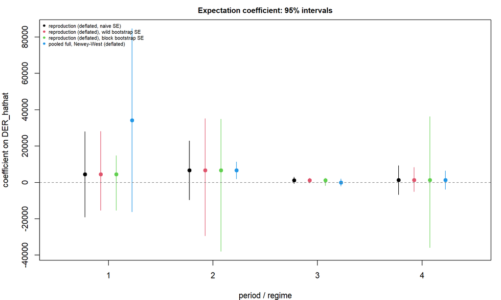

Figure 2: Expectation coefficient of Model I by period: 95% intervals from the conventional standard error, the wild and the block bootstrap (percentile), and the pooled model with Newey-West standard errors. Headline specification. Source: own estimates.

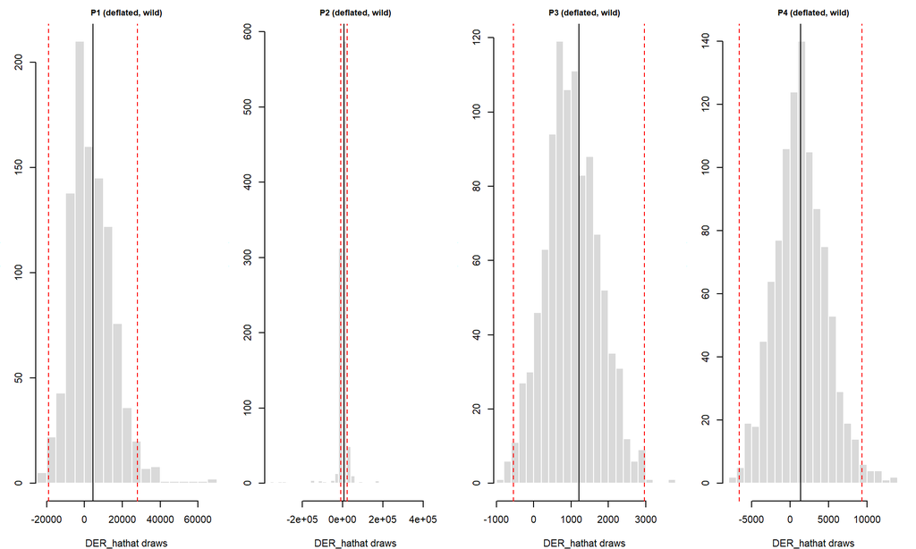

Figure 3: Wild-bootstrap distribution of the Model I expectation coefficient by period. Solid line: point estimate; dashed lines: conventional 95% interval. Source: own estimates.

## 5.5 Stage-2 constant

This correction is not in the original replication plan and was added after the first corrected estimates had been seen (W4-20), for the reasons below, and is reported as a separate step, so that its effect can be seen. Stage 2 (2, 3) has no constant. A regression without a constant forces its fitted values through the origin. If the exchange-rate change has a drift, as in the managed-appreciation periods, the slope must then fit the drift as well as the month-to-month persistence, and it is biased towards the value that reproduces the mean (omitted intercept bias). We add a constant to stage 2 on the corrected data (row 4c of Table 14). For Model I, the bootstrap, log-difference and pooled rows on the corrected data build on it. Model II has no stage 2.

With one stage-2 lag, as in the headline specification, the expectation regressor is $\hat c + \hat a\,\Delta ER_{t-1}$ with a constant and $\hat a_0\,\Delta ER_{t-1}$ without one. Stage 3 has its own constant, so

$$\tau_0 + \tau_1\,(\hat c + \hat a\,\Delta ER_{t-1}) = (\tau_0 + \tau_1 \hat c) + \beta\,\Delta ER_{t-1}, \qquad \beta = \tau_1 \hat a ,$$

and stage 3 fits the same model with either regressor. Only the units of the coefficient change: $\hat\tau_1=\hat\beta/\hat a$, with a standard error scaled by the same factor. The stage-2 constant therefore leaves the *t*-statistic and the *p*-value of the expectation coefficient unchanged and multiplies the coefficient by $\hat a_0/\hat a$. In Table 14, rows 4 and 4c have the same *p*-value in 3 of 3 periods with an identified coefficient. The coefficient changes by the factor -7.11 in Period 2, 2.48 in Period 3 and 1.58 in Period 4: from 1,617.78 (SE 5,345.07) to -11,500.37 (SE 37,996.62), from 3,831.09** (SE 1,219.03) to 9,497.90** (SE 3,022.19), and from 2,528.37 (SE 4,448.86) to 3,997.40 (SE 7,033.72).

The same identity explains the bootstrap. Because $\hat\tau_1 = \hat\beta/\hat a$, its sampling distribution has long tails when $\hat a$ is close to zero relative to its sampling error: some replications divide by a number near zero. Recovered from rows 4 and 4c by the identity, the stage-2 slope with a constant is -0.015, 0.331 and 0.364 in Periods 2 to 4. Without the constant it is 0.108, 0.820 and 0.575 (standard errors 0.100, 0.127 and 0.122). The ratio of the wild-bootstrap to the conventional standard error of the expectation coefficient (row 5) is 1.74, 78.29 and 76.84 in Periods 2 to 4.

Our interpretation suggests that, once a constant absorbs the drift, little month-to-month persistence of the exchange-rate change remains within a regime, so the size of a Model I expectation effect is weakly identified. In Period 3 the coefficient is insignificant under the wild bootstrap with the constant and insignificant without it, so its bootstrap significance does not depend on the constant either.

## 5.6 Year-to-date GDP

In the appendix, the GDP of every month of a quarter is the cumulative GDP of the year to date. Its first difference is therefore zero in two months of each quarter, positive at each quarter start, and strongly negative every January, when the cumulation restarts. This January fall is an accounting artefact that enters both models as a regressor. The correction replaces it by discrete quarterly GDP (the difference of consecutive year-to-date values), held in each month of the quarter (W4-05). The code first verifies that the appendix value is constant within every quarter. The effect is shown in row 3 of Table 14 and Table 15, to be compared with row 1b, the reproduction on the same (raw) data. Under the headline specification, GDP enters neither stage 2 nor stage 3 of Model I, so rows 1b and 3 of Table 14 coincide; the correction matters for Model II, where GDP is a regressor.

## 5.7 Deflator

The article divides every variable by $\pi/100$. Here $\pi$ is the consumer price index with the same month of the previous year = 100, a year-on-year growth factor $P_t/P_{t-12}$ rather than a price level (National Bureau of Statistics of China 2024). Dividing by it gives $X_t P_{t-12}/P_t$: the real value multiplied by last year’s price level, not a real series. The correction divides the value variables (FER, GDP, net exports, FDI, external debt and the balance of payments) by a fixed-base consumer price index, rebased to 2000 = 100, from the IMF. The exchange rate and the NDF are not deflated: they are prices of one currency in another, and a real exchange rate would require both countries’ price levels (W4-05).[^2]

The article divides the exchange rates, the balance of payments, GDP, reserves, net exports, foreign debt, FDI and the NDF by $\pi$, but not the interest rate, which it labels real (p. 334). The deflated data version of this replication divides every model variable except $\pi$ itself, including the interest rate, as the replication plan specifies (W4-24). The interest rate enters only in stage 1. Under the headline’s stage 2 (the alternative form), stage 1 does not enter the expectation regressor, so the difference does not affect the headline Model I estimates or Model II. It does affect the stage-1 regressions, and with them the Durbin-Watson comparison of Section 4 and the BOP selection rule (W2-03).

We check the price data in two ways (Table 10 and Figure 4). First, we compare the original $\pi$ with the same-month year-on-year index published by the National Bureau of Statistics (NBS): 144 of 144 months agree within the printed decimals, with a largest gap of 0.000 points (W4-14). Every month agrees. The original $\pi$ is therefore the NBS published index with the same month of the previous year = 100, a growth factor, which confirms the premise of this correction. Second, the year-on-year rates implied by the IMF index agree with the published ones within the printed decimals in 31 of 144 months (largest gap 0.592 points).[^3] Our interpretation suggests, as a hypothesis, that the gaps arise because the published year-on-year rates and the IMF index are computed from different rounded inputs: the NBS publishes rates to one decimal, and an index chained from rounded rates accumulates rounding error. Gaps concentrated around the years in which the NBS reweights its basket (National Bureau of Statistics of China 2024) would instead point to the reweighting. We did not test either explanation, and neither affects the correction, which uses the index level.

Table 10: Consumer-price checks, 2000-2011. Within print: gap no larger than half a unit of the last decimal printed in the original document. Source: original Appendix I; IMF; FRED; NBS; own calculations.

| check | n | mean abs gap | max abs gap | n within print | correlation |
| --- | --- | --- | --- | --- | --- |
| original pi vs IMF CPI year-on-year | 144 | 0.0764 | 0.5922 | 31 | 0.9989 |
| IMF vs FRED CPI year-on-year (sample months) | 144 | 0.0000 | 0.0000 |  | 1.0000 |
| IMF / FRED index ratio (constant if same index, other base) | 144 | 0.0000 | 0.0000 |  |  |
| original pi vs NBS published year-on-year | 144 | 0 | 0 | 144 | 1 |
| NBS published year-on-year vs IMF CPI year-on-year | 144 | 0.0764 | 0.5922 | 31 | 0.9989 |

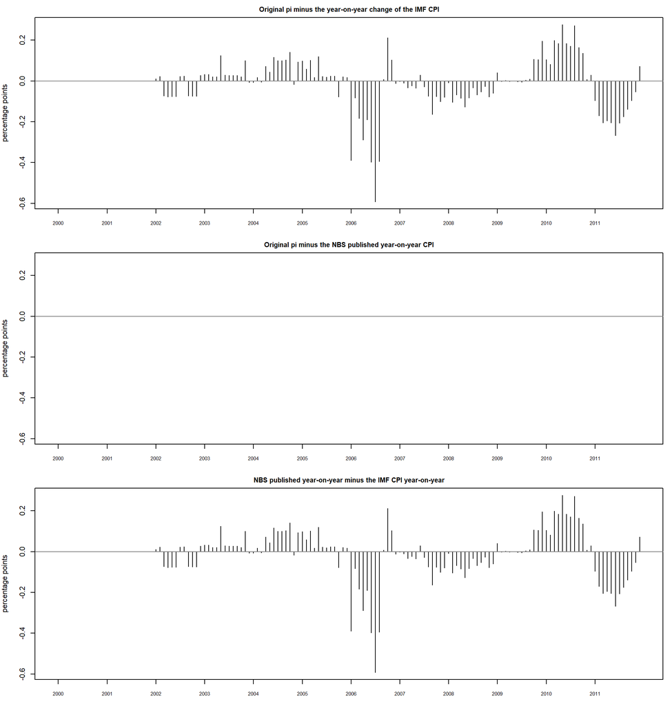

Figure 4: Gaps between the original inflation series, the NBS published year-on-year CPI and the year-on-year rate implied by the IMF CPI index, 2000-2011. Source: original Appendix I; NBS; IMF; own calculations.

## 5.8 Period 1: exchange-rate variation

From January 2000 to June 2005 the RMB was pegged to the US dollar, and the appendix exchange rate is constant (standard deviation 0.000 on raw data). Its change is zero, so no expectation effect can be estimated from it: the coefficient is not identified (W3-10). In the article’s deflated data the exchange rate varies (standard deviation 0.138), and that variation comes from the deflator: the $R^2$ of the deflated exchange-rate change on the change of $\pi$ is 0.999 (Table 11). A Period 1 “expectation effect” estimated on deflated data is therefore an effect of inflation. With the exchange rate undeflated (the corrected data), the Period 1 coefficient of Model I is reported as not identified. Model II is not affected: the NDF is a market price that varies in Period 1, and its coefficient is estimated in every row (on the corrected data it is positive and insignificant).

Table 11: Period 1: variation of the exchange rate, its change, and the stage-3 expectation term, by data version. Source: own calculations.

| version | stage2 const | sd ER level | sd DER | sd DER hathat | r2 DER on Dpi |
| --- | --- | --- | --- | --- | --- |
| raw | FALSE | 0 | 0 | 0 |  |
| deflated | FALSE | 0.1379 | 0.0530 | 0.0006 | 0.9991 |
| gdpq | FALSE | 0 | 0 | 0 |  |
| corrected | TRUE | 0 | 0 | 0 |  |

## 5.9 Unit-root test label

The article and the text of the original document call the unit-root test an ADF test; the original tables report DF-GLS tests.

## 5.10 Chow tests, correctly specified

The classic Chow test (Chow 1960) assumes equal error variances in the two regimes and no autocorrelation. Both assumptions are doubtful with monthly data across exchange-rate regimes. The corrected test estimates one regression over 2000–2011 in which every coefficient is regime-specific (Section 5.11), and tests the equality of all coefficients of two adjacent regimes with a Wald test based on Newey–West standard errors (last column of Table 9; Table 12). For the corrected data, Model I, the tests give: regimes 1–2, *F*(4, 117) = 2.95, *p* = 0.023; regimes 2–3, *F*(5, 117) = 3.78, *p* = 0.003; regimes 3–4, *F*(5, 117) = 0.43, *p* = 0.828. For Model II, in the same order: *F*(6, 116) = 5.70, *p* < 0.001; *F*(6, 116) = 14.12, *p* < 0.001; *F*(6, 116) = 4.12, *p* < 0.001. At the 5% level, the robust test rejects the equality of all Model I coefficients between Regimes 1 and 2, rejects it between Regimes 2 and 3, and does not reject it between Regimes 3 and 4. For Model II, in the same order, the test rejects, rejects, and rejects equality. Our interpretation suggests that the regime split is supported where the test rejects. Two reservations apply. Each test uses a Newey-West covariance that is estimated from few months in Regime 2 (Section 5.11). And a rejection says that some coefficient changes, not that the expectation coefficient does (that test is reported in Section 5.11).

## 5.11 Period 2: pooled model with regime interactions

Period 2 has about a year of monthly observations and five or six regressors, leaving very few residual degrees of freedom. Following the replication plan, the four periods are pooled in one regression with regime-specific constants. In the *full* variant every coefficient is regime-specific, which gives the same point estimates as separate OLS regressions for each period, with one covariance matrix for the whole sample (W4-02). In the original document, the regressions of Periods 1 and 3 have AR(1) errors. The pooled model is estimated by OLS, so its Period 1 and Period 3 coefficients differ from those of the separate regressions. A difference between row 7 and the earlier rows in those periods reflects the error model as well as the standard errors. In the *expectation-only* variant only the constant and the expectation term are regime-specific and the controls are common (W4-02). Standard errors are Newey–West, with a lag of 4 (Newey and West 1987, 1994) (W4-03).

The Newey-West covariance is built from the products of residuals and regressors within each regime, so in the short regimes it rests on a dozen or so monthly products. Its two versions disagree there. For example, for the NDF coefficient of Model II in Regime 4 on the deflated data, the automatic-bandwidth standard error (Newey and West 1994) is 0.22 times the rule-lag one. By the condition stated in advance (W4-03), the rule lag stays primary, and we treat the per-regime significance of the pooled model as unreliable in the short regimes (W4-32). For the Model I expectation coefficient in Regime 2 on the deflated data, the Newey-West standard error is 0.09 times the OLS one, and the coefficient is positive and significant at row 7. We do not read that significance as evidence of an effect.

The expectation-only variant is valid only if the controls have the same effect in every regime. The Wald test of that restriction in the full model gives *F*(9, 117) = 3.77, *p* < 0.001 for Model I and *F*(12, 116) = 2.54, *p* = 0.005 for Model II (corrected data). The test that the expectation coefficient is the same in all regimes gives *F*(2, 117) = 0.88, *p* = 0.418 (Model I) and *F*(3, 116) = 2.04, *p* = 0.113 (Model II). At the 5% level, the test rejects equal controls for Model I and rejects them for Model II. Where it rejects, the expectation-only variant imposes a false restriction, and the fully interacted variant is the appropriate one. The test of an equal expectation coefficient in all regimes does not reject equality for Model I and does not reject it for Model II. In the fully interacted model on the corrected data, the Regime 2 expectation coefficient is negative and insignificant in Model I and positive and insignificant in Model II. Our interpretation suggests that pooling does not reveal a Period 2 expectation effect that the separate regressions miss for lack of degrees of freedom.

Table 12: Pooled models, 2000-2011, with regime interactions and Newey-West standard errors; corrected data. Source: own estimates.

|  | I full | I exp only | II full | II exp only |
| --- | --- | --- | --- | --- |
| Expectation term, regime 1 |  |  | -108.413 | -114.522 |
|  |  |  | (222.666) | (223.579) |
| Expectation term, regime 2 | -11500.372 | 7721.769 | 255.077 | 1033.171** |
|  | (10294.444) | (16800.601) | (279.787) | (375.196) |
| Expectation term, regime 3 | -944.544 | -789.315 | 157.154 | 94.700 |
|  | (3324.729) | (3128.457) | (351.161) | (278.148) |
| Expectation term, regime 4 | 3997.398 | 4267.694 | -1545.268* | -1649.303* |
|  | (6033.135) | (5703.711) | (736.126) | (705.806) |
| DGDP (common) |  |  |  | 0.003 |
|  |  |  |  | (0.002) |
| DNX (common) |  | 0.390 |  | 0.443 |
|  |  | (0.414) |  | (0.369) |
| DFDB (common) |  | 0.643*** |  | 0.507*** |
|  |  | (0.144) |  | (0.136) |
| DFDI (common) |  | -0.176 |  | -0.476 |
|  |  | (0.834) |  | (0.880) |
| All coefficients equal, regimes 1-2 | F(4, 117) = 2.95, p = 0.023 |  | F(6, 116) = 5.70, p < 0.001 |  |
| All coefficients equal, regimes 2-3 | F(5, 117) = 3.78, p = 0.003 |  | F(6, 116) = 14.12, p < 0.001 |  |
| All coefficients equal, regimes 3-4 | F(5, 117) = 0.43, p = 0.828 |  | F(6, 116) = 4.12, p < 0.001 |  |
| Controls equal in all regimes | F(9, 117) = 3.77, p < 0.001 |  | F(12, 116) = 2.54, p = 0.005 |  |
| Expectation term equal in all regimes | F(2, 117) = 0.88, p = 0.418 | F(2, 126) = 0.36, p = 0.700 | F(3, 116) = 2.04, p = 0.113 | F(3, 128) = 5.05, p = 0.002 |
| N (Newey-West lag) | 136 (4) | 136 (4) | 140 (4) | 140 (4) |

<sup>a</sup> Pooled OLS over 2000-2011, data version ‘corrected’, level form, with regime-specific constants. full: every coefficient regime-specific (point estimates equal the separate per-period OLS fits; controls not shown); exp_only: only the constant and the expectation term regime-specific, controls common.  
<sup>b</sup> Newey-West standard errors in parentheses: Bartlett kernel, lag floor(4(n/100)^(2/9)), no prewhitening, small-sample factor n/(n-k); p-values from t(n-k). Results with the automatic bandwidth are in corr_pooled_coefs.csv and corr_pooled_tests.csv.  
<sup>c</sup> Tests: Wald tests with the Newey-West covariance, reported as F = W/q with (q, n-k) degrees of freedom. A term not identified in a regime is left out of the restrictions.  
<sup>d</sup> Model I uses the stage-3 expected change of the exchange rate from the headline specification, with a constant in stage 2 (decision W4-20); its pooled standard errors do not account for the generated regressor (see Table 3 for the bootstrap).  
<sup>e</sup> Significance (legend of original Tables 4.9-4.10): † p < 0.1, * p < 0.05, ** p < 0.01, *** p < 0.001 (two-sided; normal for the ARIMA periods, t for OLS).  
<sup>f</sup> Periods: 1 = 2000-01 to 2005-06; 2 = 2005-07 to 2006-05; 3 = 2006-06 to 2008-05; 4 = 2008-06 to 2011-12 (Replication Plan s.3.3).

## 5.12 Interest-rate label

The article calls the interest rate “real”. The appendix series is the nominal one-year deposit rate; Table 2 uses the correct label. The label does not affect any estimate.

## 5.13 NDF source

The article does not state the source of its NDF series. We use the 12-month USD/CNY NDF from Wind, identified by its Wind code in Table 3 (W2-06).[^4]

## 5.14 Corrected estimates

Table 13 reports both models on the corrected data (discrete quarterly GDP, fixed-base CPI, exchange rates undeflated) with the original study’s estimators. For Model I it also shows the wild-bootstrap standard error of the expectation term.

Table 13: Corrected estimates. Source: own estimates.

|  | P1 I | P1 II | P2 I | P2 II | P3 I | P3 II | P4 I | P4 II |
| --- | --- | --- | --- | --- | --- | --- | --- | --- |
| Expected DER (stage 3) | n.i. |  | -11500.372 |  | 9497.903** |  | 3997.398 |  |
|  |  |  | (37996.620) |  | (3022.191) |  | (7033.721) |  |
|  |  |  | (65931.884) |  | (236604.080) |  | (540492.984) |  |
| DNDF |  | 8.040 |  | 255.077 |  | -385.753 |  | -1545.268** |
|  |  | (119.602) |  | (769.289) |  | (329.122) |  | (491.406) |
| DGDP |  | 0.001 |  | -0.004 |  | -0.007* |  | 0.006 |
|  |  | (0.003) |  | (0.008) |  | (0.003) |  | (0.005) |
| DNX | -0.150 | -0.199 | 1.960† | 1.504 | -0.221 | 0.435 | 0.289 | 0.317 |
|  | (0.412) | (0.487) | (0.756) | (1.264) | (0.337) | (0.356) | (0.705) | (0.643) |
| DFDB | -0.086 | -0.097 | -0.845 | -0.056 | 0.678*** | 0.705*** | 0.763* | 0.571† |
|  | (0.207) | (0.232) | (0.656) | (1.694) | (0.154) | (0.168) | (0.333) | (0.287) |
| DFDI | -0.127 | -0.126 | -0.969 | 0.728 | -0.588 | -0.407 | -0.111 | -0.730 |
|  | (0.580) | (0.672) | (2.170) | (4.253) | (0.918) | (1.114) | (2.752) | (2.334) |
| Constant | 84.746*** | 82.372*** | 60.525 | 161.886* | 698.319*** | 233.389* | 243.956* | 184.648*** |
|  | (23.151) | (23.495) | (377.506) | (35.796) | (180.480) | (94.118) | (115.971) | (45.278) |
| AR(1) | 0.572*** | 0.581*** |  |  | 0.893*** | 0.742† |  |  |
|  | (0.074) | (0.073) |  |  | (0.222) | (0.447) |  |  |
| N | 64 | 65 | 9 | 10 | 22 | 23 | 41 | 42 |

<sup>a</sup> Data version ‘corrected’: discrete quarterly GDP; FER, GDP, NX, FDI, FDB and BOP divided by the IMF consumer price index (2000 = 100); exchange rates, inflation and the interest rate not deflated.  
<sup>b</sup> Model I: alternative stage-2 regressor, 1 lag(s) (the headline specification), with a constant in stage 2 (step 4c, a correction outside Plan s.5; decision W4-20); same estimators as the original (ARIMA(1,0,0) by ML in Periods 1 and 3, OLS in Periods 2 and 4).  
<sup>c</sup> Second line: conventional standard error (OPG in the ARIMA periods). Third line, expectation term of Model I only: wild-bootstrap standard error of the whole three-stage chain (999 replications), marks from the centred bootstrap p-value.  
<sup>d</sup> n.i. = not identified (no variation of the exchange rate under the Period 1 peg when it is not deflated).  
<sup>e</sup> Significance (legend of original Tables 4.9-4.10): † p < 0.1, * p < 0.05, ** p < 0.01, *** p < 0.001 (two-sided; normal for the ARIMA periods, t for OLS).  
<sup>f</sup> Periods: 1 = 2000-01 to 2005-06; 2 = 2005-07 to 2006-05; 3 = 2006-06 to 2008-05; 4 = 2008-06 to 2011-12 (Replication Plan s.3.3).

# 6 Effect on the conclusions

Tables 14 (Model I) and 15 (Model II) follow the expectation coefficient through the corrections, one step at a time. Row 0 is the published value, row 1 our reproduction, and row 1b the same on raw data. Row 1c is a diagnostic, not a correction: the reproduction with a constant in stage 2 (W4-19); the headline remains row 1. Rows 3 to 6 each add one correction to the row before, with the comparisons 1 → 1b (the article’s deflation), 1b → 3 (GDP), 3 → 4 (fixed-base CPI), 4 → 4c (a constant in stage 2, a correction outside the replication plan; W4-20) and 4c → 6 (log differences). Rows 2 and 5 replace the conventional standard errors by bootstrap ones, and row 7 is the pooled model; for Model I on the corrected data, rows 5 to 7 include the stage-2 constant. Model II has no stage 2, so rows 1c and 4c do not apply to it, and its row 6 follows row 4.

We read the tables with the rule of the reproduction (W1-07). A step changes the result if the coefficient gains or loses significance, or changes sign while either estimate is significant. Along the main chain (row 0, 1, 1b, 3, 4, 4c and 6; Model II without 4c), and from row 1 or row 4c (Model II: row 4) to the wild bootstrap (row 2 and 5) and the fully interacted pooled model (row 7), the changes are (W4-30):

- Model I, Period 1: no change; Period 2: significance gained at 1 → 7 (full deflated); Period 3: significance gained at 3 → 4; significance lost at 4c → 5 (wild); significance lost at 4c → 7 (full corrected); Period 4: no change.
- Model II, Period 1: no change; Period 2: no change; Period 3: no change; Period 4: significance lost at 1 → 7 (full deflated).

Table 14: Model I: the expectation coefficient through the corrections. Source: original Tables 4.9-4.10; own estimates.

| step | P1 | P2 | P3 | P4 |
| --- | --- | --- | --- | --- |
| 0 original (published marks; parentheses read as SE) | 328.303 | 164.243 | -200.074 | -4308.484 |
|  | (188.021) | (1192.054) | (476.606) | (8324.331) |
| 1 reproduction (deflated, naive SE) | 4485.078 | 6689.584 | 1206.454 | 1345.527 |
|  | (11990.643) | (8297.936) | (895.225) | (4083.291) |
| 1b reproduction (raw, naive SE) | n.i. | -763.137 | 2493.153 | -77.046 |
|  |  | (7808.640) | (1634.046) | (5465.999) |
| 1c reproduction + stage-2 constant (diagnostic W4-19) | 4900.731 | 2745.829 | 12269.121 | 1480.258 |
|  | (13101.870) | (3405.999) | (9104.056) | (4492.159) |
| 2 reproduction (deflated), wild bootstrap SE | 4485.078 | 6689.584 | 1206.454 | 1345.527 |
|  | (11535.178) | (37171.864) | (717.761) | (3328.714) |
| 2 reproduction (deflated), block bootstrap SE | 4485.078 | 6689.584 | 1206.454 | 1345.527 |
|  | (36363.766) | (119596.112) | (1039.882) | (201117.002) |
| 3 + discrete quarterly GDP (raw) | n.i. | -763.137 | 2493.153 | -77.046 |
|  |  | (7808.640) | (1634.046) | (5465.999) |
| 4 + fixed-base CPI, ER/NDF undeflated | n.i. | 1617.783 | 3831.087** | 2528.375 |
|  |  | (5345.071) | (1219.035) | (4448.864) |
| 4c + stage-2 constant (outside Plan s.5, W4-20) | n.i. | -11500.372 | 9497.903** | 3997.398 |
|  |  | (37996.620) | (3022.191) | (7033.721) |
| 5 corrected + stage-2 constant, wild bootstrap SE | n.i. | -11500.372 | 9497.903 | 3997.398 |
|  |  | (65931.884) | (236604.080) | (540492.984) |
| 6 corrected + stage-2 constant, log differences | n.i. | -8.612 | 4.829** | 1.612 |
|  |  | (31.691) | (1.719) | (2.130) |
| 7 pooled full, Newey-West (deflated) | 34215.270 | 6689.584** | -27.844 | 1345.527 |
|  | (25718.927) | (2401.193) | (1031.056) | (2599.255) |
| 7 pooled full, Newey-West (corrected + stage-2 constant) | n.i. | -11500.372 | -944.544 | 3997.398 |
|  |  | (10294.444) | (3324.729) | (6033.135) |
| 7 pooled exp_only, Newey-West (deflated) | 36057.963 | 1397.526 | 209.036 | 971.008 |
|  | (29456.536) | (6048.973) | (1008.926) | (2413.424) |
| 7 pooled exp_only, Newey-West (corrected + stage-2 constant) | n.i. | 7721.769 | -789.315 | 4267.694 |
|  |  | (16800.601) | (3128.457) | (5703.711) |

<sup>a</sup> Coefficient on the stage-3 expected change of the exchange rate (Model I) in each period (step 7: in each regime of the pooled model), standard error below in parentheses.  
<sup>b</sup> Step 0: original, with the significance marks as printed and the numbers in parentheses read as standard errors (decision W4-28). Step 1: our reproduction (headline data version). Step 1b: the same on raw data. Steps 3-6 add one correction at a time (README_week4 s.2.1): 1b to 3 isolates the GDP correction, 3 to 4 the fixed-base CPI.  
<sup>c</sup> Step 1c is a diagnostic, not a correction (decision W4-19): the reproduction of step 1 re-estimated with a constant in stage 2, to test whether the original’s stage 2 had one; the reproduction itself (step 1) is unchanged. Step 4c is a correction outside Plan s.5 (decision W4-20): step 4 with a constant in stage 2; for Model I, steps 5, 6 and the pooled model on the corrected data build on 4c.  
<sup>d</sup> Steps 2 and 5: bootstrap standard error of the whole three-stage chain (999 replications; wild: Rademacher; block: moving blocks within periods); marks from the centred bootstrap p-value.  
<sup>e</sup> Step 6: coefficients are elasticities (log differences of FER and of the exchange-rate terms). Step 7: pooled OLS 2000-2011 with regime-specific constants and expectation terms; full = all coefficients regime-specific; exp_only = controls common; Newey-West standard errors.  
<sup>f</sup> n.i. = not identified.  
<sup>g</sup> Significance (legend of original Tables 4.9-4.10): † p < 0.1, * p < 0.05, ** p < 0.01, *** p < 0.001 (two-sided; normal for the ARIMA periods, t for OLS).  
<sup>h</sup> Periods: 1 = 2000-01 to 2005-06; 2 = 2005-07 to 2006-05; 3 = 2006-06 to 2008-05; 4 = 2008-06 to 2011-12 (Replication Plan s.3.3).

Table 15: Model II: the NDF coefficient through the corrections. Source: original Tables 4.9-4.10; own estimates.

| step | P1 | P2 | P3 | P4 |
| --- | --- | --- | --- | --- |
| 0 original (published marks; parentheses read as SE) | 109.567 | 305.763 | -163.185 | -1294.446* |
|  | (117.109) | (395.505) | (376.356) | (531.200) |
| 1 reproduction (deflated, naive SE) | 111.435 | 255.190 | -154.820 | -1288.885* |
|  | (116.916) | (402.890) | (343.054) | (531.095) |
| 1b reproduction (raw, naive SE) | 21.164 | 314.185 | -446.921 | -2092.133** |
|  | (123.751) | (957.873) | (623.886) | (603.384) |
| 1c reproduction + stage-2 constant (diagnostic W4-19) | — | — | — | — |
| 3 + discrete quarterly GDP (raw) | 23.508 | 397.918 | -405.853 | -2010.491** |
|  | (115.146) | (854.193) | (408.803) | (608.944) |
| 4 + fixed-base CPI, ER/NDF undeflated | 8.040 | 255.077 | -385.753 | -1545.268** |
|  | (119.602) | (769.289) | (329.122) | (491.406) |
| 4c + stage-2 constant (outside Plan s.5, W4-20) | — | — | — | — |
| 6 corrected, log differences | -0.102 | 0.304 | -0.222 | -0.471** |
|  | (0.260) | (0.670) | (0.152) | (0.165) |
| 7 pooled full, Newey-West (deflated) | 121.166 | 255.190 | 213.801 | -1288.885 |
|  | (157.159) | (260.325) | (295.889) | (852.932) |
| 7 pooled full, Newey-West (corrected) | -108.413 | 255.077 | 157.154 | -1545.268* |
|  | (222.666) | (279.787) | (351.161) | (736.126) |
| 7 pooled exp_only, Newey-West (deflated) | 127.298 | 513.629* | 289.480 | -1267.534 |
|  | (152.845) | (243.321) | (289.850) | (811.580) |
| 7 pooled exp_only, Newey-West (corrected) | -114.522 | 1033.171** | 94.700 | -1649.303* |
|  | (223.579) | (375.196) | (278.148) | (705.806) |

<sup>a</sup> Coefficient on DNDF (Model II) in each period (step 7: in each regime of the pooled model), standard error below in parentheses.  
<sup>b</sup> Step 0: original, with the significance marks as printed and the numbers in parentheses read as standard errors (decision W4-28). Step 1: our reproduction (headline data version). Step 1b: the same on raw data. Steps 3-6 add one correction at a time (README_week4 s.2.1): 1b to 3 isolates the GDP correction, 3 to 4 the fixed-base CPI.  
<sup>c</sup> Steps 1c and 4c (a stage-2 constant, decisions W4-19 and W4-20) concern stage 2 of Model I; Model II has no stage 2, so they do not apply (—).  
<sup>d</sup> No bootstrap for Model II: its expectation regressor is observed, not generated.  
<sup>e</sup> Step 6: coefficients are elasticities (log differences of FER and of the exchange-rate terms). Step 7: pooled OLS 2000-2011 with regime-specific constants and expectation terms; full = all coefficients regime-specific; exp_only = controls common; Newey-West standard errors.  
<sup>f</sup> n.i. = not identified.  
<sup>g</sup> Significance (legend of original Tables 4.9-4.10): † p < 0.1, * p < 0.05, ** p < 0.01, *** p < 0.001 (two-sided; normal for the ARIMA periods, t for OLS).  
<sup>h</sup> Periods: 1 = 2000-01 to 2005-06; 2 = 2005-07 to 2006-05; 3 = 2006-06 to 2008-05; 4 = 2008-06 to 2011-12 (Replication Plan s.3.3).

For reference, the Model II coefficient of Period 4 is -1,294.45* (SE 531.20) as published, -1,288.88* (SE 531.10) in our reproduction, -1,545.27** (SE 491.41) on the corrected data, and -0.471** (SE 0.165) as an elasticity. For Model I, Period 3, it is -200.07 (SE 476.61) as published, 1,206.45 (SE 895.23) reproduced, and 9,497.90** (SE 3,022.19) corrected (with the stage-2 constant), with a wild-bootstrap standard error of 236,604.08 (*p* = 0.593).

**Model II, Period 4.** The one expectation coefficient that the article reports as significant is significant at the steps 0 (-), 1 (-), 1b (-), 3 (-), 4 (-), 6 (-), 7 (full corrected) (-), 7 (exp_only corrected) (-) (step, sign). It keeps its significance and its sign through every per-period correction: the article’s deflation, the GDP construction, the deflator and the log form. It loses significance only in the pooled model on the deflated data, where the per-regime standard errors are unreliable (W4-32). Its sign is negative, opposite to the abstract’s “positive” (Section 5). Our interpretation suggests that this finding is robust to the corrections. It is an association between reserve growth and a market price observed at the time, not necessarily a causal effect (W4-21).

**Sensitivity to the differencing convention.** Under the convention fixed before estimation (first differences on the whole series; Section 4), 8 cells of the step tables differ in significance, or in a significant sign, from the results above (W4-31): Model I, Period 2, step 7 (full corrected); Model I, Period 2, step 7 (full deflated); Model I, Period 3, step 1b; Model I, Period 3, step 3; Model I, Period 3, step 4; Model I, Period 3, step 4c; Model I, Period 3, step 6; Model I, Period 3, step 7 (full corrected). No Model II cell differs. The headline Model I specification also differs between the conventions (W3-07, W4-27). Our interpretation suggests that the Model I results are fragile, while the Model II result is robust and does not depend on how the period samples are built.

**The article’s statements.** (1) The significant recent effect of the first conclusion survives for the NDF in Period 4. Its sign agrees with the published table (p. 339), Section 4.3.2 (p. 341) and the first conclusion (p. 342), but not with the abstract’s “positive” correlation (p. 327) or the word “positive” in Section 4.3.1 (p. 340); we read those two descriptions as errors (Section 5, sign convention). Its counterpart, no significant effect before June 2006, holds for every per-period estimate of Periods 1 and 2, but Model I cannot be assessed in Period 1. (2) The regime explanation of the signs (p. 341) rests on coefficients that are insignificant in the original and in our estimates, and their signs carry no conclusion (W1-07). (3) The structural change of the second conclusion cannot rest on the published Chow statistics, which are not reproduced. The robust test of Section 5 bears on it. (4) The policy recommendation of the third conclusion presupposes a causal effect that single-equation estimates of this kind cannot establish (W4-21). Model I’s expectation is an in-sample fitted value that uses information from after the month it describes (W4-17), which we identify as a limitation of Model I.

# 7 Reproducibility and data availability

Every result in this note is produced by the code in the replication package, https://github.com/du-jc/fer-replication, at commit 8bf3498, with R version 4.5.3 (2026-03-11 ucrt) and the package versions recorded in `renv.lock`; the tables and figures were generated on 2026-10-08. The code starts from the raw files and runs in a fixed order; each script writes a run log. The bootstrap uses a fixed seed, so reruns give identical draws.[^5] A complete run from a fresh clone of the repository, with only the original document and the Wind export added, reproduced every result table and figure: identical, or identical up to the order of rows and the record of the run’s date, commit and time stamps (W4-38).

Public data (SAFE, IMF, FRED, NBS) are included in the package with their download dates and checksums (Table 3). Two inputs are not included. The original document is unpublished work of the original authors; its reproduction targets (the numbers of its tables) are included in the package as `original_targets.csv` (W4-08). The Wind NDF series is proprietary and is required to build the analysis panel: without it, the first estimation script (`01_import_verify.R`) stops, and no estimate can be reproduced (W4-23). A reader with Wind access can export the series using the code in Table 3, register it with `register_wind.py`, and run the package unchanged.

# 8 Conclusion

We reproduced the published estimates of Du, Ge and Qiao (2014) from the data of the original document. Of the 20 Model I estimates, 18 are reproduced under our rule, and of the Model II estimates 23 of 24. Many of these agree because both the published and our estimates are insignificant (Section 4). The controls and the autoregressive error terms reproduce closely. Model I’s expectation term reproduces only in that weak sense, because it is a generated regressor built from choices the original does not report. The published constants are consistent with variables divided by $\pi$ rather than $\pi/100$, a diagnosis found after the results were seen (W4-26). The Durbin-Watson, Breusch-Godfrey and Chow statistics are not reproduced, while 124 of 168 Durbin-Watson and Breusch-Godfrey test decisions are.

We found and corrected errors of three kinds. The first are errors of reporting: standard errors labelled as *t*-statistics, level coefficients read as percentages, a sign described inconsistently, and an ADF label on DF-GLS tests. The second are errors of data construction: a year-on-year inflation factor used as a deflator, year-to-date GDP whose differences fall every January, and Period 1 “variation” in the exchange rate that comes from the deflator. The third are errors of inference: standard errors that ignore the estimation of the generated regressor, Chow statistics that cannot be reproduced, and a period too short to estimate. We also added a constant to stage 2 (Section 5.5).

The article’s central empirical finding, a significant relation between the NDF and reserve growth in 2008-2011, survives every per-period correction. Its sign is negative: reserves grew faster when the forward market priced appreciation, contrary to the abstract’s “positive” relation. The model-based expectation of Model I shows no robust effect in any period, and the regime-based interpretation of the signs rests on insignificant coefficients (Section 6).

Several questions remain open. Model I’s expectation is an in-sample fitted value: it uses information from after the month it describes (W4-17). An expectation formed in real time, with the data available at each date, is the natural test, and it requires longer samples than the original’s periods. The article’s conceptual model has reserves affecting the exchange rate, a loop that single-equation estimates do not identify (W4-21). Both questions are left for future work with data for 2000-2025. Within this replication, the original’s construction of its Model I samples (W4-18), the size of its Chow statistics (W3-13) and the regressions behind its Durbin-Watson statistics remain unexplained.

# References

Aizenman, Joshua, and Jaewoo Lee. 2007. “International Reserves: Precautionary Versus Mercantilist Views, Theory and Evidence.” *Open Economies Review* 18 (2): 191–214. https://doi.org/10.1007/s11079-007-9030-z.

Chow, Gregory C. 1960. “Tests of Equality Between Sets of Coefficients in Two Linear Regressions.” *Econometrica* 28 (3): 591–605. https://doi.org/10.2307/1910133.

Davidson, Russell, and Emmanuel Flachaire. 2008. “The Wild Bootstrap, Tamed at Last.” *Journal of Econometrics* 146 (1): 162–69. https://doi.org/10.1016/j.csda.2004.05.018.

Du, Jiancheng, Jiaoju Ge, and Jin Qiao. 2014. “Impact of Renminbi Exchange Rate Expectation on China’s Foreign Exchange Reserves: An Empirical Analysis.” *International Journal of Sustainable Economy* 6 (4): 327–44. https://doi.org/10.1504/IJSE.2014.065399.

Elliott, Graham, Thomas J. Rothenberg, and James H. Stock. 1996. “Efficient Tests for an Autoregressive Unit Root.” *Econometrica* 64 (4): 813–36.

Fox, John, Sanford Weisberg, and Brad Price. 2026. *Car: Companion to Applied Regression*. https://github.com/bprice2652/car_repo.

Gohel, David, and Panagiotis Skintzos. 2026. *Flextable: Functions for Tabular Reporting*. https://ardata-fr.github.io/flextable-book/.

Hothorn, Torsten, Achim Zeileis, Richard W. Farebrother, and Clint Cummins. 2022. *Lmtest: Testing Linear Regression Models*. https://doi.org/10.32614/CRAN.package.lmtest.

International Monetary Fund. 2026. *Consumer Price Index (CPI) Dataflow, China, All Items, Index, Monthly. Dataset*. https://data.imf.org.

Künsch, Hans R. 1989. “The Jackknife and the Bootstrap for General Stationary Observations.” *The Annals of Statistics* 17 (3): 1217–41. https://doi.org/10.1214/AOS/1176347265.

Mammen, Enno. 1993. “Bootstrap and Wild Bootstrap for High Dimensional Linear Models.” *The Annals of Statistics* 21 (1): 255–85. https://doi.org/10.1214/AOS/1176349025.

Murphy, Kevin M., and Robert H. Topel. 1985. “Estimation and Inference in Two-Step Econometric Models.” *Journal of Business & Economic Statistics* 3 (4): 370–79. https://doi.org/10.2307/1391724.

National Bureau of Statistics of China. 2024. *CPI 的编制方法 [How the CPI Is Compiled]*. National Bureau of Statistics of China, statistical knowledge series. https://www.stats.gov.cn/zs/tjws/zytjzbqs/jmxxggzs/202411/t20241127_1957589.html.

National Bureau of Statistics of China. 2026. *Consumer Price Index, Same Month of the Previous Year = 100, Monthly. Dataset*. https://data.stats.gov.cn.

Newey, Whitney K., and Kenneth D. West. 1987. “A Simple, Positive Semi-Definite, Heteroskedasticity and Autocorrelation Consistent Covariance Matrix.” *Econometrica* 55 (3): 703–8. https://doi.org/10.2307/1913610.

Newey, Whitney K., and Kenneth D. West. 1994. “Automatic Lag Selection in Covariance Matrix Estimation.” *The Review of Economic Studies* 61 (4): 631–53. https://doi.org/10.2307/2297912.

Obstfeld, Maurice, Jay C. Shambaugh, and Alan M. Taylor. 2010. “Financial Stability, the Trilemma, and International Reserves.” *American Economic Journal: Macroeconomics* 2 (2): 57–94. https://doi.org/10.1257/mac.2.2.57.

Organisation for Economic Co-operation and Development. 2026. *Consumer Price Index: Total for China (CHNCPIALLMINMEI), Retrieved from FRED, Federal Reserve Bank of St. Louis. Dataset*. https://fred.stlouisfed.org/series/CHNCPIALLMINMEI.

Pagan, Adrian. 1984. “Econometric Issues in the Analysis of Regressions with Generated Regressors.” *International Economic Review* 25 (1): 221–47. https://doi.org/10.2307/2648877.

Pfaff, Bernhard. 2024. *Urca: Unit Root and Cointegration Tests for Time Series Data*. https://doi.org/10.32614/CRAN.package.urca.

Prasad, Eswar, and Shang-Jin Wei. 2007. *The Chinese Approach to Capital Inflows: Patterns and Possible Explanations*. None. None. NBER Chapters. National Bureau of Economic Research, Inc. https://doi.org/None.

R Core Team. 2026. *R: A Language and Environment for Statistical Computing*. R Foundation for Statistical Computing. https://www.R-project.org/.

State Administration of Foreign Exchange. 2026. *China’s Balance of Payments, Time Series (BPM6), Quarterly. Dataset*. https://www.safe.gov.cn.

Wind Information Co. 2026. *USD/CNY Non-Deliverable Forward, 12 Months, Daily (Wind Code in the Source Ledger). Dataset*. https://www.wind.com.cn.

Xie, Yihui. 2026. *Knitr: A General-Purpose Package for Dynamic Report Generation in r*. https://yihui.org/knitr/.

Zeileis, Achim, Friedrich Leisch, Kurt Hornik, and Christian Kleiber. 2026. *Strucchange: Testing, Monitoring, and Dating Structural Changes*. https://zeileis.codeberg.page/strucchange/.

Zeileis, Achim, and Thomas Lumley. 2026. *Sandwich: Robust Covariance Matrix Estimators*. https://zeileis.codeberg.page/sandwich/.

## Appendix A. Decisions cited

Table 16: Decisions in the author’s decision log. Each entry gives the options considered, the evidence and the date; the log is available on request. Source: docs/decisions_index.csv, written from the log by make_decisions_index.py.

| Decision | Title | Date |
| --- | --- | --- |
| W1-01 | Location of the extracted appendix | 2026-10-06 |
| W1-02 | The original document (.docx) is not committed | 2026-10-06 |
| W1-03 | Wind NDF data | 2026-09-27 |
| W1-04 | Image-label map | 2026-10-06 |
| W1-05 | Provenance of the original document (.docx) | 2026-10-06 |
| W1-06 | Software environment | 2026-10-06 |
| W1-07 | Classification of reproduction status | 2026-10-06 |
| W1-08 | Weekly READMEs are not committed | 2026-10-06 |
| W1-09 | The decisions log is not committed | 2026-10-06 |
| W1-10 | The week-summary script is not committed | 2026-10-06 |
| W2-01 | BOP selection rule: combining DF-GLS and DW | 2026-10-06 |
| W2-02 | DF-GLS specification: calibrate on the original-study variables, then fix | 2026-10-06 |
| W2-03 | Data version for the stage-1 DW in the BOP rule | 2026-10-06 |
| W2-04 | Quarterly-to-monthly BOP conversions | 2026-10-06 |
| W2-05 | Differencing and period samples | 2026-10-06 |
| W2-06 | NDF: source file, checks and monthly versions | 2026-10-06 |
| W2-07 | Verification tolerance | 2026-10-06 |
| W2-08 | Where the analysis panel lives | 2026-10-06 |
| W2-09 | Result: DF-GLS specification selected | 2026-10-06 |
| W2-10 | Result: NDF version and BOP candidate selected | 2026-10-06 |
| W2-11 | SAFE BPM6 vintage used | 2026-10-06 |
| W2-12 | BOP series: current account only | 2026-10-06 |
| W2-13 | Tables 3.2-3.9 verification | 2026-10-06 |
| W3-01 | Differencing convention (completes W2-05) | 2026-10-06 |
| W3-02 | Rule naming the Model I specification that reproduces Tables 4.9-4.10 | 2026-10-06 |
| W3-03 | ARIMA(1,1,0) estimation and standard errors | 2026-10-06 |
| W3-04 | Stage 2 without a constant | 2026-10-06 |
| W3-05 | Chow tests: as specified, plus diagnostic variants | 2026-10-06 |
| W3-06 | Breusch-Godfrey specification | 2026-10-06 |
| W3-07 | Result: Model I specification reproducing Tables 4.9-4.10 | 2026-10-06 |
| W3-08 | Result: Model II classification | 2026-10-06 |
| W3-09 | Result: DW, BG and Chow against Tables 4.3-4.8 and 4.11 | 2026-10-06 |
| W3-10 | Raw Period 1: expectation coefficient not identified | 2026-10-06 |
| W3-11 | Sample sizes differ from the original N; within convention closer | 2026-10-06 |
| W3-12 | DW and BG statistics not reproduced to print | 2026-10-06 |
| W3-13 | Chow F statistics: degrees of freedom partly matched, magnitudes not | 2026-10-06 |
| W3-14 | Reproduced counts rest largely on insignificant cells | 2026-10-06 |
| W3-15 | Week 3 code and outputs committed | 2026-10-06 |
| W4-01 | Bootstrap for the generated regressors | 2026-10-06 |
| W4-02 | Pooled model with regime interactions | 2026-10-06 |
| W4-03 | Newey-West settings | 2026-10-06 |
| W4-04 | Scope of the corrections | 2026-10-06 |
| W4-05 | Data corrections: GDP, CPI, logs | 2026-10-06 |
| W4-06 | Selection rules for the note tables | 2026-10-06 |
| W4-07 | History check stricter than the Blueprint | 2026-10-06 |
| W4-08 | Publishing original_targets.csv; the decisions log | 2026-10-06 |
| W4-09 | Licence and rendered files | 2026-10-06 |
| W4-11 | Primary convention after Week 4 (follow-up to W3-11) | 2026-10-08 |
| W4-13 | renv sandbox switched off | 2026-10-06 |
| W4-14 | NBS published year-on-year CPI as a check of the original pi | 2026-10-06 |
| W4-15 | W3-14 settled: subsets reported in the note | 2026-10-06 |
| W4-16 | Meaning of the dagger in Tables 4.9-4.10 | 2026-10-08 |
| W4-17 | Look-ahead in the Model I expectation | 2026-10-08 |
| W4-18 | Model I sample sizes fit neither differencing convention | 2026-10-08 |
| W4-19 | Diagnostic: did the original's stage 2 have a constant? | 2026-10-08 |
| W4-20 | Correction step outside Plan s.5: stage-2 constant in the corrected Model I | 2026-10-08 |
| W4-21 | Stage 1 omits FER although the conceptual model has FER -> ER | 2026-10-08 |
| W4-23 | Without the Wind export the package does not run | 2026-10-08 |
| W4-22 | Result: the stage-2 constant diagnostic (W4-19) | 2026-10-08 |
| W4-10 | Result: corrections that change the conclusions | 2026-10-08 |
| W4-24 | Scope of the 'deflated' data version | 2026-10-08 |
| W4-25 | W3-09 completed: n implied by the Table 4.3 dL/dU | 2026-10-08 |
| W4-26 | Constants: the published constants equal ours rescaled by 1/100 (post-hoc diagnosis) | 2026-10-08 |
| W4-27 | Primary convention changed to within (the condition of W4-11 is met) | 2026-10-08 |
| W4-28 | Row 0 of the step tables shows the published marks | 2026-10-08 |
| W4-29 | Result: the stage-2 constant diagnostic for the within headline (W4-19 under W4-27) | 2026-10-08 |
| W4-30 | Result: corrections that change the conclusions, primary convention within (supersedes W4-10) | 2026-10-08 |
| W4-31 | Sensitivity: within (primary) against full | 2026-10-08 |
| W4-32 | Newey-West: rule lag and automatic bandwidth disagree (W4-03 "would change if") | 2026-10-08 |
| W4-33 | Purpose of the report and AI-use disclosure | 2026-10-13 |
| W4-34 | W3-12 and W3-13 confirmed | 2026-10-13 |
| W4-35 | Repository and sharing (completes W4-12) | 2026-10-13 |
| W4-37 | History check result (completes W4-07) | 2026-10-13 |
| W4-38 | Clean-clone reproduction test | 2026-10-13 |
| W4-39 | Study A frozen | 2026-10-13 |
| W4-40 | The rendered note is committed (supersedes the rendered-files part of W4-09) | 2026-10-13 |

## Footnotes

[^1]: The original document predates SAFE’s BPM6 presentation and probably used BPM5 data. For the current account, the series used here, the BPM5 and BPM6 are identical over the sample period (W2-12), so the accounting standard does not explain a mismatch.
[^2]: The US-dollar variables are thereby deflated by China’s consumer prices, which measures their purchasing power over Chinese goods.
[^3]: We compared the FRED series with the IMF’s in the same way (largest year-on-year gap 0.0000). The FRED series carries the same index as the IMF’s, rebased (their ratio is constant up to rounding; W4-05). It therefore confirms the download but is not an independent measure.
[^4]: Wind lists the series as compiled from news reports; its 1-, 3- and 6-month tenors start only at the end of 2008, so the 12-month tenor is the only one covering the sample.
[^5]: Python collects and registers the data; R estimates. Each script writes a run log to `outputs/logs/`.